# ABC Supermarkets Survey

https://github.com/VictoriaUniversity-AU/assessment-1-Cathy-2022.git

2022-08-08

### Use parse_number() to covert purchase.price, total.cost,sold.price and total.sales to number, remove $ signs

```r
ABC_Supermarket <- read.csv("Survey data.csv")
ABC_Supermarket %>%
  group_by(suplier) %>%
  ungroup()
```

```
## # A tibble: 726 × 17
##    Itemid Itemname    Store.type    suplier  suplier.location quantity Item.sold
##     <int> <chr>       <chr>         <chr>    <chr>               <dbl>     <dbl>
##  1   2234 "Oranges"   Grocery       " Groce… " VIC "              1618      2461
##  2   2235 "Apples"    Orchard       " Compl… " NSW  "             1321      2656
##  3   2236 "Bananas"   Grocery       " Japan… " Queensland "       2178       949
##  4   2237 "Lettuce"   Market        " Basfo… " Tasmania "          888      2137
##  5   2238 "Tomatoes"  Market        " Kahve… " Western Austr…     2470       336
##  6   2239 "Squash"    Market        " NSM F… " South Austral…     1513      1606
##  7   2240 "Celery"    Grocery       " Bera … " Northern Terr…      921      1309
##  8   2241 "Cucumber"  Market        " Groce… " The Australia…     2518      2166
##  9   2242 "Mushrooms" Grocery       " Compl… " NSW  "             1899       876
## 10   2243 "Milk "     Home Delivery " Japan… " Queensland "       1545      2458
## # … with 716 more rows, and 10 more variables: purchase.price <chr>,
## #   total.cost <chr>, sold.price <chr>, Discounts <chr>, total.sales <chr>,
## #   Date <chr>, Month.Number <int>, Month.Name <chr>, Year <int>,
## #   other.feedback <chr>
```

```r
ABC_df <- ABC_Supermarket %>%
  mutate(purchase_price_num = parse_number(purchase.price),
         total_cost_number = parse_number(total.cost),
         sold_price_num = parse_number(sold.price),
         total_sales_num = parse_number(total.sales)
         )
```

### 1.What are the top 5 company items that have more demand based on items sold

```r
top_items <- ABC_Supermarket %>%
  group_by(suplier,Itemname) %>%
  summarise(
    number=n(),
    item_sum = sum(Item.sold, na.rm = TRUE)
  ) %>%
  ungroup()
top_items <- top_items %>%
  arrange(-item_sum) %>%
  head(5) %>%
  select(Itemname,suplier, item_sum)
top_items
```

```
## # A tibble: 5 × 3
##   Itemname suplier                                  item_sum
##   <chr>    <chr>                                       <dbl>
## 1 Tomatoes " Japan Foods Trading "                    18765
## 2 Lettuce  " Grocery Industries Australia Pty Ltd "   18078.
## 3 Bananas  " Grocery Industries Australia Pty Ltd "   17481
## 4 Bananas  " Basfoods Direct "                        16572.
## 5 Oranges  " Japan Foods Trading "                    16228.
```

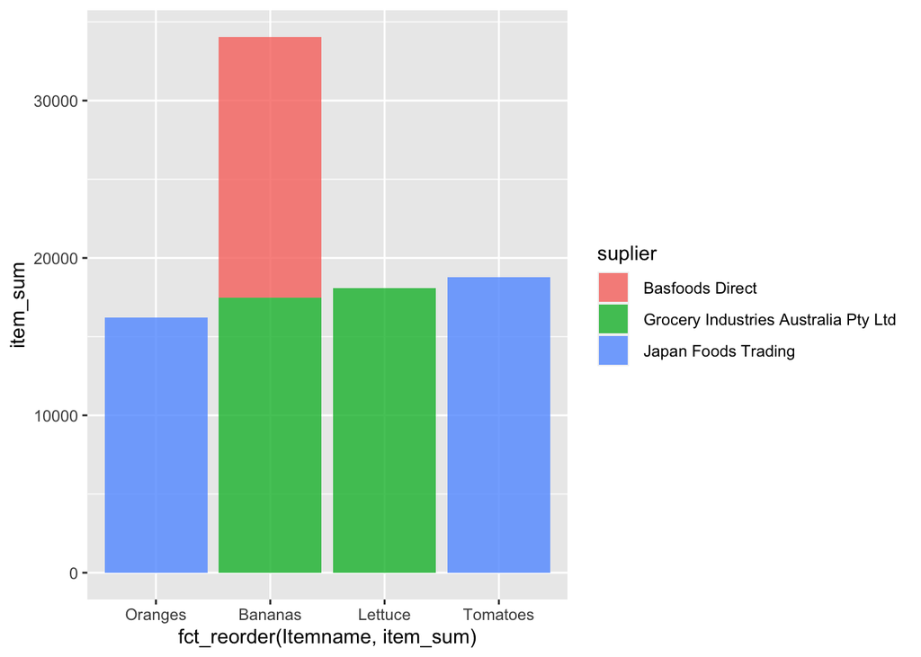

```r
top_items %>%
  ggplot(
  aes(fct_reorder(Itemname, item_sum), item_sum, fill = suplier)) +
  geom_col(alpha = 0.8)
```

```r
top_sales <- ABC_df %>%
  group_by(suplier,Itemname) %>%
  summarise(
    number=n(),
    total_sales_sum = sum(total_sales_num, na.rm = TRUE),
    total_cost_sum = sum(total_cost_number, na.rm = TRUE)
  ) %>%
  ungroup()
top_sales <- top_sales %>%
  arrange(-total_sales_sum) %>%
  head(5) %>%
  select(Itemname,suplier, total_sales_sum)
top_sales
```

```
## # A tibble: 5 × 3
##   Itemname  suplier                                     total_sales_sum
##   <chr>     <chr>                                                 <dbl>
## 1 Tomatoes  " Japan Foods Trading "                             159454.
## 2 Lettuce   " Grocery Industries Australia Pty Ltd "            157482.
## 3 Squash    " Basfoods Direct "                                 154137.
## 4 Mushrooms " NSM Foods Direct to Public Outlet Store "         144293.
## 5 Bananas   " Basfoods Direct "                                 132224.
```

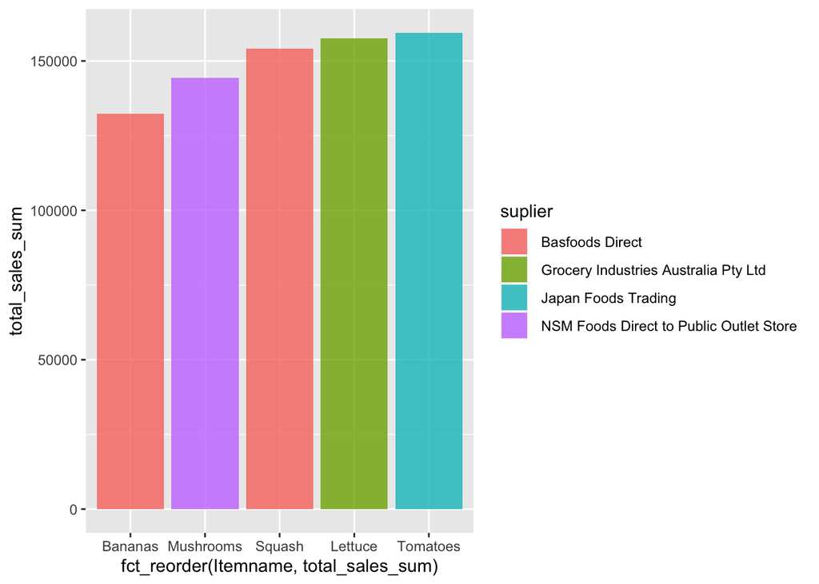

```r
top_sales %>%
  ggplot(
  aes(fct_reorder(Itemname, total_sales_sum), total_sales_sum, fill = suplier)) +
  geom_col(alpha = 0.8)
```

### 2.Finding out the top 5 profitable items and giving these items sales line chart to find it sale’s trend.

```r
ABC_df <- ABC_df %>%
  mutate(profit = total_sales_num - total_cost_number,
         year_month= Year*100 +Month.Number)

profit <- ABC_df %>%
  group_by(Itemname) %>%
  summarise(item_profit= sum(profit),
            item_sold= sum(Item.sold),
            ) %>%
  ungroup()

profit %>% arrange(-item_profit) %>%
  head(5)
```

```
## # A tibble: 5 × 3
##   Itemname item_profit item_sold
##   <chr>          <dbl>     <dbl>
## 1 Oranges      129626.   109860
## 2 Bananas      116456.    99142
## 3 Squash       102183.    76470
## 4 Lettuce       95076.    91044.
## 5 Tomatoes      70185.    95736.
```

```r
top_profit <- ABC_df %>% group_by(Itemname,year_month) %>%
  summarise(total_profit= sum(profit),
            total_sales = sum(total_sales_num)) %>%
  filter( Itemname=="Squash" |
           Itemname == "Bananas" |
           Itemname == "Oranges" |
           Itemname == "Lettuce" |
           Itemname == "Tomatoes"
         )
```

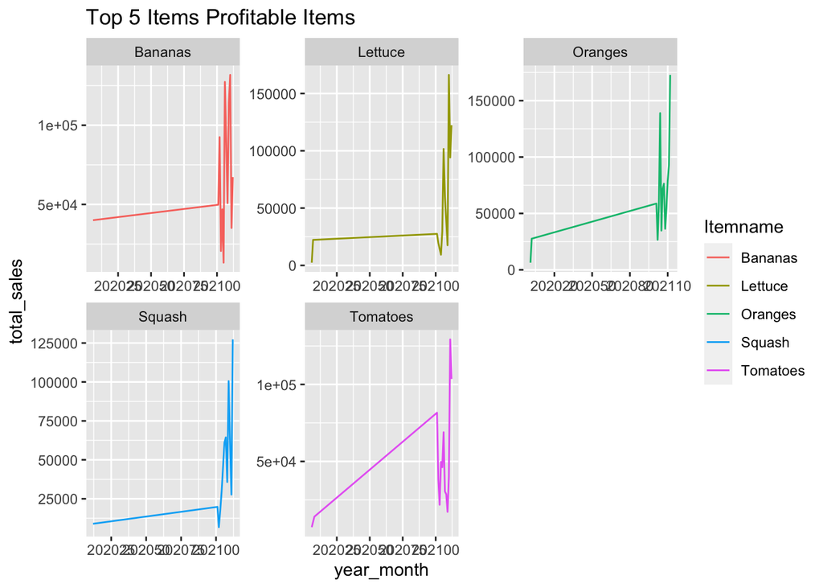

```r
top_profit %>% ggplot(
  aes(year_month,total_sales,colour=Itemname,fill=Itemname)
  )+
  geom_line()+
  facet_wrap(~ Itemname, scales = "free") +
  ggtitle("Top 5 Items Profitable Items")
```

### 3. Finding out 5 lowest profitable items, giving the 5 lowest items sales line chart to find it sale’s trend.

```r
profit %>% arrange(item_profit) %>%
  head(5)
```

```
## # A tibble: 5 × 3
##   Itemname   item_profit item_sold
##   <chr>            <dbl>     <dbl>
## 1 Celery          27612.    41348.
## 2 Mushrooms       31384.    51630.
## 3 Cheese          36933.    46555
## 4 Sour cream      37276.    58238
## 5 Cucumber        37886.    47128.
```

```r
low_profit <- ABC_df %>% group_by(Itemname,year_month) %>%
  summarise(total_profit= sum(profit),
            total_sales = sum(total_sales_num)) %>%
  filter( Itemname=="Celery" |
           Itemname == "Mushrooms" |
           Itemname == "Cheese" |
           Itemname == "Sour cream" |
           Itemname == "Cucumber"
         )
```

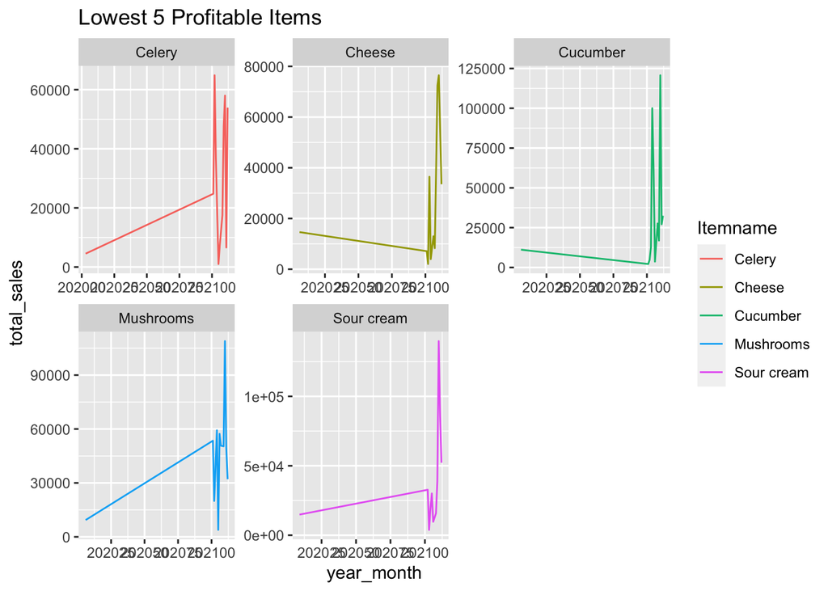

```r
low_profit %>% ggplot(
  aes(year_month,total_sales,colour=Itemname,fill=Itemname)
  )+
  geom_line()+
  facet_wrap(~ Itemname, scales = "free") +
  ggtitle("Lowest 5 Profitable Items")
```

### 4.Finding the total sales per month for each year, finding which month has the highest sales comparing to other months.

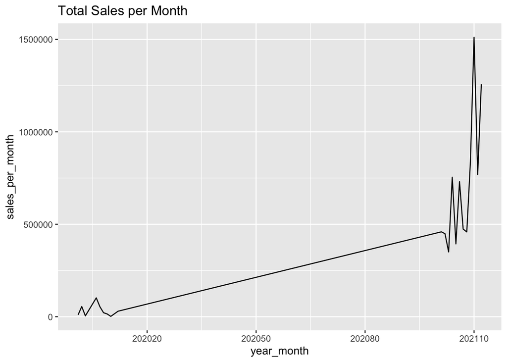

```r
sale_pm <- ABC_df %>%
  group_by(year_month) %>%
  summarise(sales_per_month = sum(total_sales_num)
    ) %>%
  arrange(year_month)

sale_pm %>%
  ggplot(
  aes(year_month,sales_per_month,fill=sales_per_month)
  )+
  geom_line()+
  ggtitle("Total Sales per Month")
```

### Comparing total sales for each year.

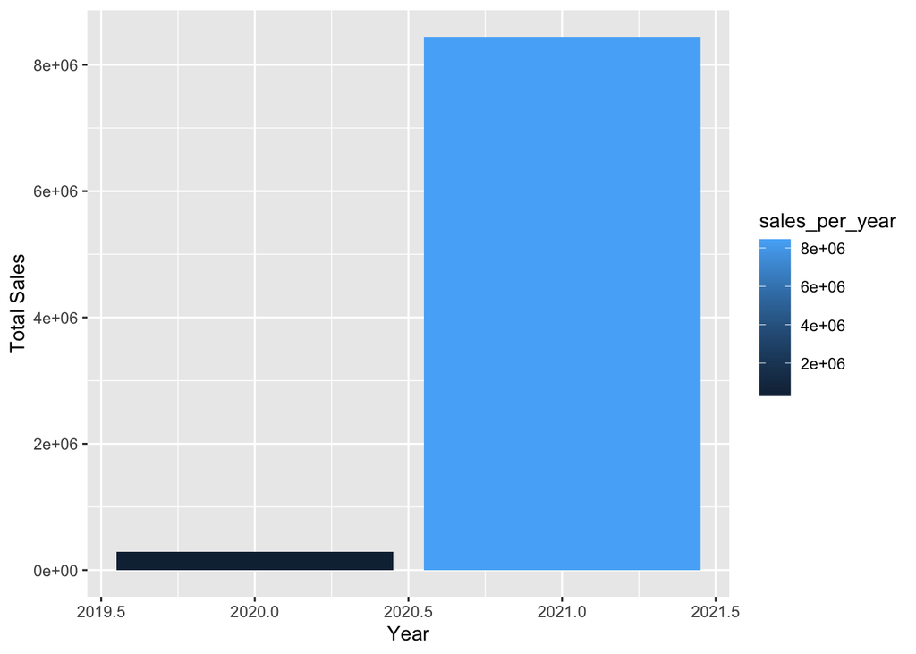

```r
sales_year <- ABC_df %>%
  group_by(Year) %>%
  summarise(sales_per_year = sum(total_sales_num)
  )
sales_year %>%  ggplot(
  aes(x = Year, y = sales_per_year, fill = sales_per_year)
  )+
  geom_col() +
  labs(y = "Total Sales")
```

```r
  ggtitle("Total Sales per Year")
```

```
## $title
## [1] "Total Sales per Year"
##
## attr(,"class")
## [1] "labels"
```

```r
growth_rate <- sales_year %>% mutate(
         Diff_year = Year - lag(Year),
         Diff_growth = sales_per_year - lag(sales_per_year),
         Rate_percent = (Diff_growth / Diff_year)/sales_per_year * 100)
```

```r
ABC_lm <- ABC_df %>%
  filter(!is.na(total_sales_num))

lm_abc = lm(total_sales_num ~other.feedback, data=ABC_lm)
summary(lm_abc)
```

```
##
## Call:
## lm(formula = total_sales_num ~ other.feedback, data = ABC_lm)
##
## Residuals:
##    Min     1Q Median     3Q    Max
## -12685  -7800  -3968   3760  55025
##
## Coefficients:
##                                                                           Estimate
## (Intercept)                                                               12712.82
## other.feedbackcustomer service was very friendly                          -2374.55
## other.feedbackgood quality                                                -1970.58
## other.feedbackI don't like this product                                     333.19
## other.feedbackI like your product                                           889.84
## other.feedbackno one response my email                                    -4247.74
## other.feedbackprodict not receive ontime                                    -68.56
## other.feedbackproduct not receive ontime                                   -261.04
## other.feedbackproduct was not very fresh thanks                            1513.26
## other.feedbackproduct was notvery fresh thanks                             -784.31
## other.feedbackproduct was very fresh thanks                               -1779.50
## other.feedbackreceive ontime                                                954.94
## other.feedbacktasty                                                        2519.80
## other.feedbackthere was an issue with my order, team resolve very quickly -2259.49
##                                                                           Std. Error
## (Intercept)                                                                  2404.65
## other.feedbackcustomer service was very friendly                             3366.51
## other.feedbackgood quality                                                   3400.68
## other.feedbackI don't like this product                                      2654.04
## other.feedbackI like your product                                            2609.65
## other.feedbackno one response my email                                       3366.51
## other.feedbackprodict not receive ontime                                     2945.08
## other.feedbackproduct not receive ontime                                     3056.25
## other.feedbackproduct was not very fresh thanks                              3366.51
## other.feedbackproduct was notvery fresh thanks                               2977.62
## other.feedbackproduct was very fresh thanks                                  2712.81
## other.feedbackreceive ontime                                                 2825.80
## other.feedbacktasty                                                          3400.68
## other.feedbackthere was an issue with my order, team resolve very quickly    3366.51
##                                                                           t value
```

[output cut: 35 more lines]

```
## other.feedbackno one response my email
## other.feedbackprodict not receive ontime
## other.feedbackproduct not receive ontime
## other.feedbackproduct was not very fresh thanks
## other.feedbackproduct was notvery fresh thanks
## other.feedbackproduct was very fresh thanks
## other.feedbackreceive ontime
## other.feedbacktasty
## other.feedbackthere was an issue with my order, team resolve very quickly
## ---
## Signif. codes:  0 '***' 0.001 '**' 0.01 '*' 0.05 '.' 0.1 ' ' 1
##
## Residual standard error: 11780 on 686 degrees of freedom
## Multiple R-squared:  0.01523,    Adjusted R-squared:  -0.003435
## F-statistic: 0.8159 on 13 and 686 DF,  p-value: 0.6435
```

```r
ABC_df %>%
  group_by(Itemname,suplier) %>%
  summarise(total_sales= sum(total_sales_num),
            item_sold= sum(Item.sold),
            ) %>%
  ungroup() %>% arrange(total_sales) %>%
  head(5)
```

```
## # A tibble: 5 × 4
##   Itemname suplier                       total_sales item_sold
##   <chr>    <chr>                               <dbl>     <dbl>
## 1 Celery   " Glendal Foods "                    697.       258
## 2 Yogurt   " Mediterranean Wholesalers "       1232.       357
## 3 Lettuce  " Bruno Fine Foods "                1494.       610
## 4 Yogurt   " Glendal Foods "                   1747.       336
## 5 Cucumber " Quality Foods "                   1750.       443
```

```r
 low_total_sales <- ABC_df %>%
   filter(grepl("Glendal Foods", suplier, ignore.case = TRUE) & Itemname =="Celery" |
          grepl("Mediterranean Wholesalers", suplier, ignore.case = TRUE) & Itemname =="Yogurt" |
          grepl("Bruno Fine Foods", suplier, ignore.case = TRUE) & Itemname =="Lettuce" |
          grepl("Glendal Foods", suplier, ignore.case = TRUE) & Itemname =="Yogurt" |
          grepl("Quality Foods", suplier, ignore.case = TRUE) & Itemname =="Cucumber"
          ) %>%
   select(Itemname,suplier,total.sales,other.feedback)

feedback_token <- low_total_sales %>%
  unnest_tokens(word,other.feedback)

nrc<- get_sentiments("nrc")
feedback_token <-feedback_token %>%
  inner_join(nrc) %>%
  rename(sentiment_nrc=sentiment) %>%
  select(Itemname,suplier,sentiment_nrc)
```

### 6.Which suppliers has the highest total sales? Did they have positive feedback?

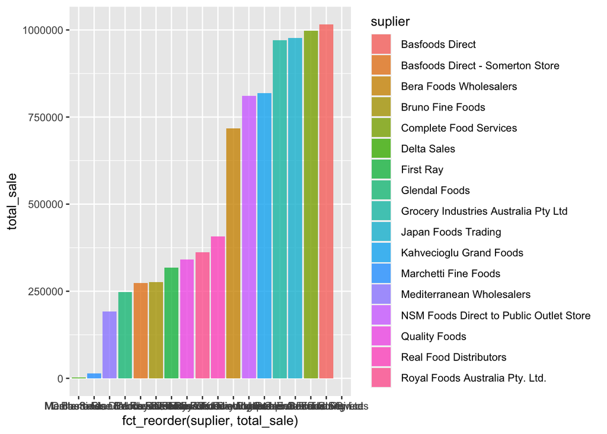

```r
sales_suplier <- ABC_df %>% filter(!is.na(total.sales)) %>%
  group_by(suplier) %>%
  summarise(total_sale=sum(total_sales_num)) %>%
  arrange(-total_sale)

sales_suplier %>% ggplot(
  aes(fct_reorder(suplier, total_sale),total_sale, fill = suplier)) +
  geom_col(alpha = 0.8)
```

```r
best_suplier <- ABC_df %>%
  filter(grepl("Basfoods Direct", suplier, ignore.case = TRUE) &
        !str_detect(suplier, "Basfoods Direct - Somerton Store"))
best_suplier %>% distinct(Itemname)
```

```
##          Itemname
## 1         Lettuce
## 2          Cheese
## 3          Apples
## 4         Bananas
## 5         Oranges
## 6        Tomatoes
## 7            Eggs
## 8       Mushrooms
## 9          Celery
## 10           Beef
## 11         Squash
## 12          Milk
## 13     Sour cream
## 14 Cottage cheese
## 15       Cucumber
## 16         Yogurt
## 17    Wild Salmon
```

```r
best_token <- best_suplier %>%
  unnest_tokens(word,other.feedback)

bing<- get_sentiments("bing")
best_token <-best_token %>%
  inner_join(bing) %>%
  rename(sentiment_bing=sentiment) %>%
  select(suplier, sentiment_bing)
```

[figure not shown]

```r
best_token <- best_token%>%
  count(sentiment_bing, sort=TRUE)%>%
  mutate(percent=paste0(round(n/sum(n)*100,2),"%"))
counts<-best_token %>% count(sentiment_bing, sort = TRUE)
ggplot(best_token, aes(x = "", y = percent, fill = sentiment_bing)) +
  geom_col() +
  geom_text(aes(label = percent),
            position = position_stack(vjust = 0.5)) +
  coord_polar(theta = "y")+
  ggtitle("Sentiment bing for best supplier")
```

### Which suppliers has the lowest total sales? Did they have negative feedback?

```r
ABC_df %>%
  filter(grepl("Delta Sales", suplier, ignore.case = TRUE)) %>%
  select(Itemname,suplier,total.sales,Item.sold,other.feedback)
```

```
##   Itemname       suplier total.sales Item.sold             other.feedback
## 1   Apples  Delta Sales   $1,793.10        258 prodict not receive ontime
```

### 7.Which supplier provided items which has the highest profit based on year.

```r
hiprofit_supplier <- ABC_df %>%
  group_by(suplier,Year) %>%
  summarise(total_profit=sum(profit)) %>%
  arrange(total_profit)
```

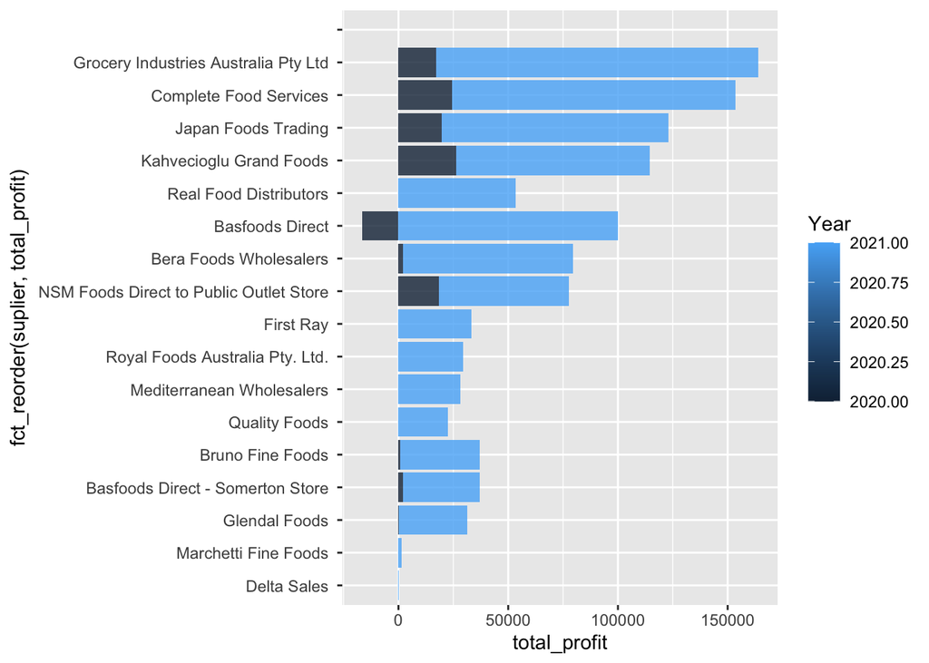

```r
hiprofit_supplier %>% ggplot(
  aes(total_profit, fct_reorder(suplier, total_profit), fill = Year)) +
  geom_col(alpha = 0.8)
```

###8.Which item’s profit increased highly in these years? Find out the top 5. Which item’s profit decreased in these years.

```r
hiprofit_item <- ABC_df %>%
  group_by(Itemname,Year) %>%
  summarise(total_profit=sum(profit)) %>%
  arrange(total_profit)
```

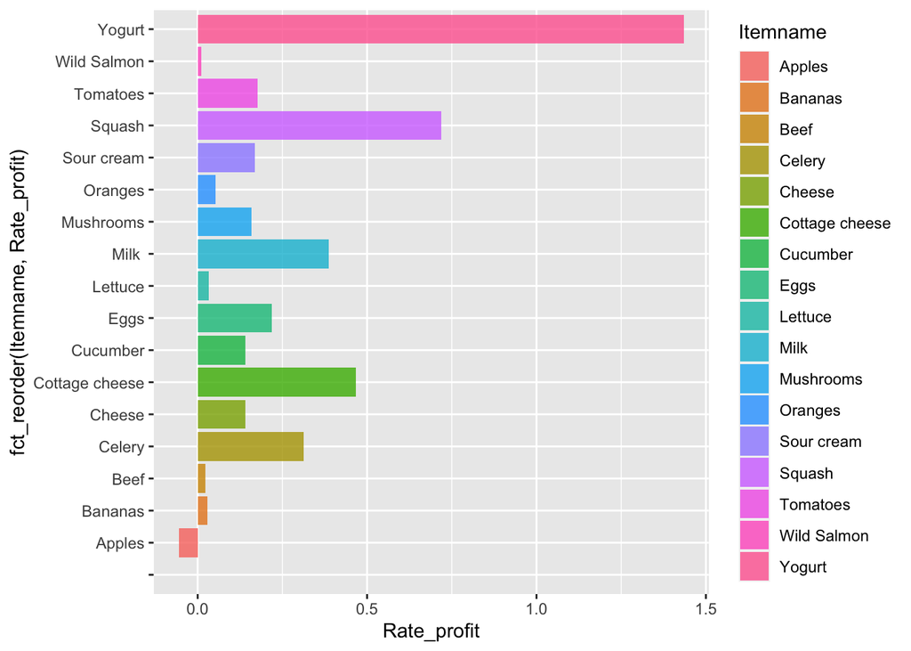

```r
growth_profit <-hiprofit_item %>%
  group_by(Itemname) %>%
  mutate(
         Diff_growth = total_profit - lag(total_profit),
         Rate_profit = (Diff_growth / lag(total_profit) /100)
  )%>%
  arrange(-Rate_profit)

growth_profit %>% ggplot(
  aes(Rate_profit, fct_reorder(Itemname, Rate_profit), fill = Itemname)) +
  geom_col(alpha = 0.8)
```